# Drug Sale Campaign

## About Drug Sale Campaign

When a new drug hits the market, not every clinician is aware of the drug treatment because there are too much information on the web these days. One way to promote a new drug awareness is through campaigns. This could be advertisements on certain medical related websites or targeted messages in certain medical software applications like a prescribing application.

This project focuses on evaluating a campaign effectiveness to promote a new drug called ‘FEELA-GOOD’ . FEELA-GOOD is a medication that relieves pain and makes you feel good. This is a special drug because it has no side effects except maybe emptying your cash wallet.We are all aware of the danger of opioids in pain management. Opioids are great for relieving pain but there are high risk of addiction and overdose that might lead to death. According to CDC, in 2021, over 75% of the approximately 107,000 drug overdose fatalities were attributed to opioids.This translates to a staggering 80,000+ lives lost to opioid overdoses in the same year, equating to an average of 220 individuals per day. It’s crucial to recognize that these figures are likely conservative estimates, and the opioid crisis is likely to escalate, as evidenced by numerous tragic overdose incidents reported in the news.

## About the Data set

This synthetic dataset gives information about the doctors’ prescription behavior and whether the doctor has seen the promotional message or not. There are only 6 columns. We will use the data to analyze if the messaging had any positive lift in ‘FEELA-GOOD’ prescriptions. There will be visuals to view data in different segments.Finally a T-test will be used to see if the campaign effect is statistically significant.

- Attribute Information
  - rx_id
    - **Meaning**: The unique ID for the prescription
    - **Variable Type**: character
    - **Possible values**: any number from 1 to infinity
  - doctor_id
    - **Meaning**: The unique ID of a doctor
    - **Variable Type**: character
    - **Possible values**: any number from 1 to infinity
  - drug_name
    - **Meaning**: Name of the drug. Could be brand or generic name.
    - **Variable Type**: character
    - **Possible values**: ‘OXYCODONE’ , ‘APIXABAN’, ‘FEELA-GOOD’,etc
  - is_pain_drug
    - **Meaning**: Is the drug used for pain or not. 1 if yes. 0 if no.
    - **Variable Type**: integer
    - **Possible values**: 1 or 0
  - is_target_drug
    - **Meaning**: Is the drug being prescribed the drug of interest? 1 if yes. 0 if no.
    - **Variable Type**: integer
    - **Possible values**: 1 or 0
  - has_seen_msg
    - **Meaning**: Did the doctor see the campaign message? 1 if yes. 0 if no.
    - **Variable Type**: integer
    - **Possible values**: 1 or 0

# Table of Contents

1. Import Packages
2. Data load and EDA
3. Graphs
4. T-test assumptions
5. T-test
6. Conclusion

# 1.Import Packages

```r
library(tidyverse)
library(data.table)
library(openxlsx)
```

utility function

```r
factorize_str <- function (dt){
  #Purpose:Temporary converts a datatable's character datatypes into factor. This way when summarize function is used, it lists out the counts of the categorical variables
  #input:(datatable)
  #output:(datatable) returns a copy of the datatable but with all the character datatypes as factors

  #Making a copy to not affect the original datatable
  dt_copy <- copy(dt)

  for (col_name in colnames(dt_copy)){
    if (is.character(dt_copy[[col_name]])){
        set(dt_copy, j = col_name, value = as.factor(dt_copy[[col_name]]))
    }
  }


  dt_copy
}
```

# 2. Data load and EDA

```r
#Read in data
df <- openxlsx::read.xlsx('dataset.xlsx')

#Convert to datatable
dt <- as.data.table(df)

#changing datatypes
dt[ , doctor_id:=as.character(doctor_id)]
dt[ , rx_id:=as.character(rx_id)]

#Adding a column to help out with analysis
dt[ , rx_event :=1]

head(dt)
```

```
##    rx_id doctor_id  drug_name is_pain_drug is_target_drug has_seen_msg rx_event
## 1:     1         1 FEELA-GOOD            1              1            1        1
## 2:     2         1 FEELA-GOOD            1              1            1        1
## 3:     3         1   APIXABAN            0              0            1        1
## 4:     4         1   APIXABAN            0              0            1        1
## 5:     5         1   APIXABAN            0              0            1        1
## 6:     6         2 FEELA-GOOD            1              1            1        1
```

```r
#view summary of dataset
summary(factorize_str(dt))
```

```
##      rx_id      doctor_id       drug_name   is_pain_drug    is_target_drug
##  1      : 1   16     : 7   APIXABAN  :46   Min.   :0.0000   Min.   :0.0000
##  10     : 1   19     : 7   FEELA-GOOD:32   1st Qu.:0.0000   1st Qu.:0.0000
##  11     : 1   7      : 7   OXYCODONE :16   Median :0.0000   Median :0.0000
##  12     : 1   20     : 6   WARFARIN  : 5   Mean   :0.4848   Mean   :0.3232
##  13     : 1   5      : 6                   3rd Qu.:1.0000   3rd Qu.:1.0000
##  14     : 1   6      : 6                   Max.   :1.0000   Max.   :1.0000
##  (Other):93   (Other):60
##   has_seen_msg       rx_event
##  Min.   :0.0000   Min.   :1
##  1st Qu.:0.0000   1st Qu.:1
##  Median :0.0000   Median :1
##  Mean   :0.4949   Mean   :1
##  3rd Qu.:1.0000   3rd Qu.:1
##  Max.   :1.0000   Max.   :1
##
```

```r
glimpse(dt)
```

```
## Rows: 99
## Columns: 7
## $ rx_id          <chr> "1", "2", "3", "4", "5", "6", "7", "8", "9", "10", "11"…
## $ doctor_id      <chr> "1", "1", "1", "1", "1", "2", "2", "2", "2", "2", "3", …
## $ drug_name      <chr> "FEELA-GOOD", "FEELA-GOOD", "APIXABAN", "APIXABAN", "AP…
## $ is_pain_drug   <dbl> 1, 1, 0, 0, 0, 1, 1, 1, 0, 0, 1, 1, 0, 0, 0, 0, 0, 1, 1…
## $ is_target_drug <dbl> 1, 1, 0, 0, 0, 1, 1, 1, 0, 0, 1, 1, 0, 0, 0, 0, 0, 0, 1…
## $ has_seen_msg   <dbl> 1, 1, 1, 1, 1, 1, 1, 1, 1, 1, 1, 1, 1, 1, 1, 1, 1, 1, 1…
## $ rx_event       <dbl> 1, 1, 1, 1, 1, 1, 1, 1, 1, 1, 1, 1, 1, 1, 1, 1, 1, 1, 1…
```

```r
#adding some columns to help out with graph generation
dt[ , intervention_group := ifelse(has_seen_msg ==1 ,'treatment','control')]
dt[ , categorical_target_value := ifelse(is_target_drug ==1 ,'target','not_target')]
dt[ , categorical_pain_value := ifelse(is_pain_drug ==1 ,'pain','not_pain')]
head(dt)
```

```
##    rx_id doctor_id  drug_name is_pain_drug is_target_drug has_seen_msg rx_event
## 1:     1         1 FEELA-GOOD            1              1            1        1
## 2:     2         1 FEELA-GOOD            1              1            1        1
## 3:     3         1   APIXABAN            0              0            1        1
## 4:     4         1   APIXABAN            0              0            1        1
## 5:     5         1   APIXABAN            0              0            1        1
## 6:     6         2 FEELA-GOOD            1              1            1        1
##    intervention_group categorical_target_value categorical_pain_value
## 1:          treatment                   target                   pain
## 2:          treatment                   target                   pain
## 3:          treatment               not_target               not_pain
## 4:          treatment               not_target               not_pain
## 5:          treatment               not_target               not_pain
## 6:          treatment                   target                   pain
```

```r
#Check if there are any NAs
round(colSums(is.na(dt)) *100/nrow(dt),1)
```

```
##                    rx_id                doctor_id                drug_name
##                        0                        0                        0
##             is_pain_drug           is_target_drug             has_seen_msg
##                        0                        0                        0
##                 rx_event       intervention_group categorical_target_value
##                        0                        0                        0
##   categorical_pain_value
##                        0
```

```r
#check if a doctor can be in the treatment and the control group
dt[ , uniqueN(intervention_group) , by ='doctor_id'][V1>1]
```

```
## Empty data.table (0 rows and 2 cols): doctor_id,V1
```

```r
#Check if there are duplicate prescriptions
dt[ , .(count=.N) , by='rx_id'][count>1]
```

```
## Empty data.table (0 rows and 2 cols): rx_id,count
```

```r
#aggregate info at doctor level
doctor_agg_dt <- dt [ , .(group=max(intervention_group ),
                          rx_cnt=.N ,
                          is_pain_drug_pct=round(sum(is_pain_drug)*100/.N,1),
                          is_target_drug_pct=round(sum(is_target_drug)*100/.N,1)),
                      by='doctor_id']
doctor_agg_dt
```

```
##     doctor_id     group rx_cnt is_pain_drug_pct is_target_drug_pct
##  1:         1 treatment      5             40.0               40.0
##  2:         2 treatment      5             60.0               60.0
##  3:         3 treatment      5             40.0               40.0
##  4:         4 treatment      5             60.0               40.0
##  5:         5 treatment      6             50.0               50.0
##  6:         6 treatment      6             50.0               33.3
##  7:         7 treatment      7             42.9               42.9
##  8:         8 treatment      4             50.0               50.0
##  9:         9 treatment      4             25.0               25.0
## 10:        10 treatment      2             50.0               50.0
## 11:        11   control      3             33.3               33.3
## 12:        12   control      4             50.0               25.0
## 13:        13   control      4             50.0               25.0
## 14:        14   control      5             60.0               20.0
## 15:        15   control      4             50.0               25.0
## 16:        16   control      7             57.1               28.6
## 17:        17   control      5             40.0               20.0
## 18:        18   control      5             40.0                0.0
## 19:        19   control      7             57.1               28.6
## 20:        20   control      6             50.0               16.7
```

# 3.Graphs

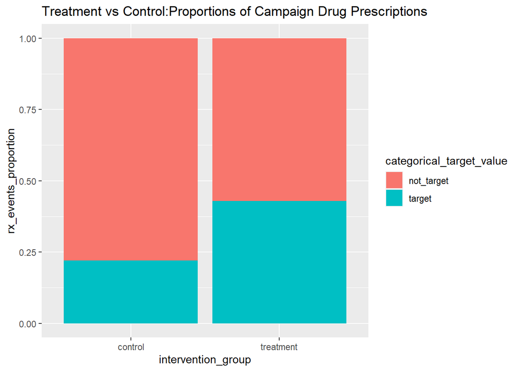

```r
# Visualize the proportion of campaign drug being  prescribed between the treatment and control group
ggplot(dt, aes (fill=categorical_target_value ,y=rx_event, x=intervention_group)) +
    geom_bar(position="fill", stat="identity") +
  labs( title = "Treatment vs Control:Proportions of Campaign Drug Prescriptions", y = "rx_events_proportion")
```

- Insight: Seems like the treatment group prescribed more of the campaign drug. Maybe the promotion was effective???

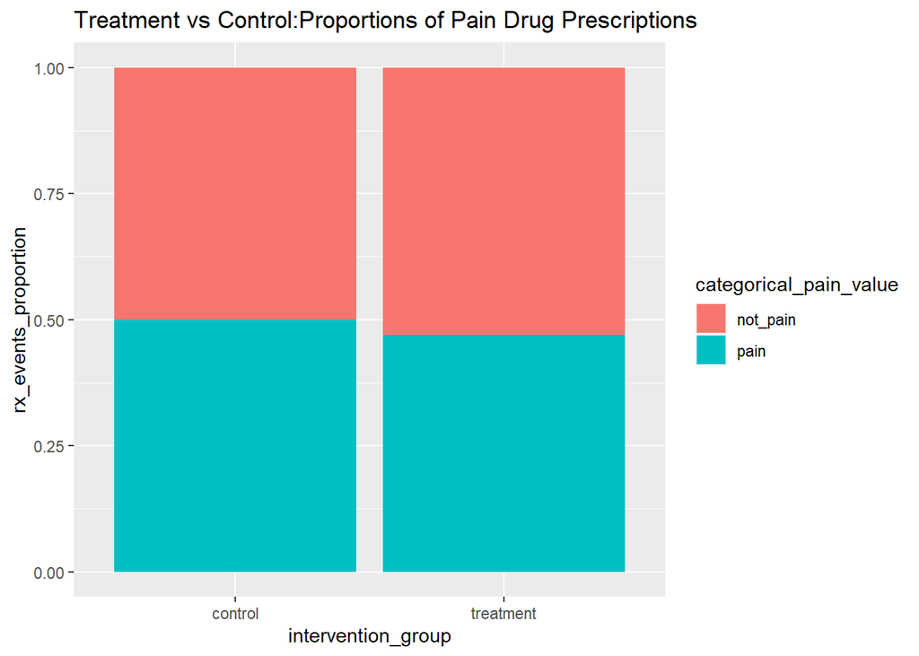

```r
# See if the treatment and control group have similiar behavior in tendency of prescribing  pain related drugs
ggplot(dt, aes (fill=categorical_pain_value ,y=rx_event, x=intervention_group)) +
    geom_bar(position="fill", stat="identity") +
  labs( title = "Treatment vs Control:Proportions of Pain Drug Prescriptions", y = "rx_events_proportion")
```

- Insight: Seems like both groups have similar tendency to prescribe pain drugs. This is important attribute.This could be a confounding variable if it wasn’t balance. We would need to do things to balance this covariate like propensity score weighting/matching.

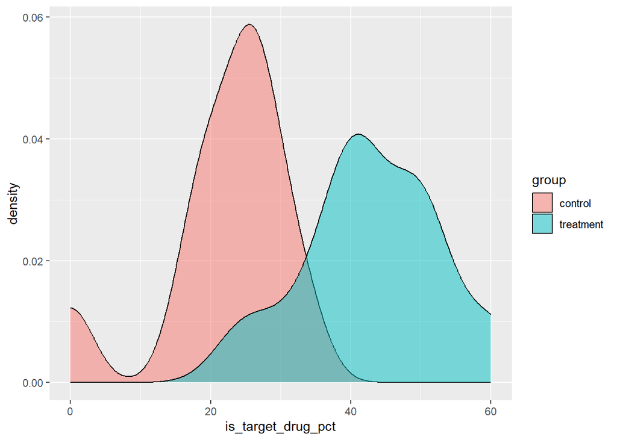

```r
# Distribution of doctors' proportion of campaign drugs being prescribed
ggplot(doctor_agg_dt, aes(x = is_target_drug_pct , fill=group)) +
  geom_density(alpha = 0.5)
```

- Insight #1: Looks almost normally distributed. This is required for T-test. - Insight #2: Looks like there could be a difference because the distributions aren’t completely overlapping.

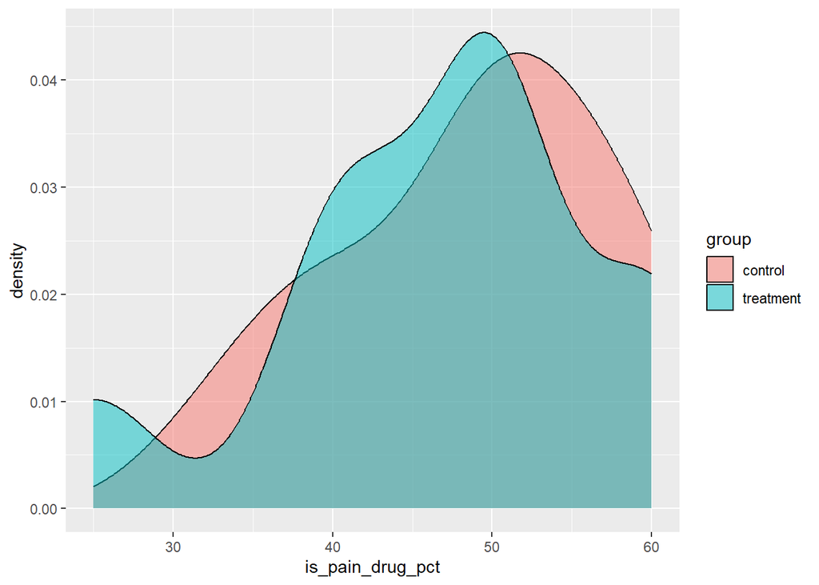

```r
# Distribution of doctors' proportion of pain prescriptions being prescribed
ggplot(doctor_agg_dt, aes(x = is_pain_drug_pct , fill=group)) +
  geom_density(alpha = 0.5)
```

- Insight:Lots of overlap. This matches the bar graphs from before, supporting the evidence that this covariate ‘is_pain_drug_pct’ is mostly balanced between two groups

```r
#See statistics at study group level
group_agg <- doctor_agg_dt[, .(rx_cnt = .N,
                                is_pain_drug_pct = mean(is_pain_drug_pct),
                                is_target_drug_pct = mean(is_target_drug_pct)),
                            by = 'group']

group_agg
```

```
##        group rx_cnt is_pain_drug_pct is_target_drug_pct
## 1: treatment     10            46.79              43.12
## 2:   control     10            48.75              22.22
```

- Insight: Seems like treatment group has much higher proportion of their prescriptions being related to the campaign

# 4.T-test assumptions

## Randomly Sample

It was fake data so probably was not randomly created. However, humans have good imagination skills so pretend this was randomly generated.

## independence

It was fake data so lets imagined each doctor didn’t really talk to each other. So doctors can’t influence each others behavior.

## Normalilty

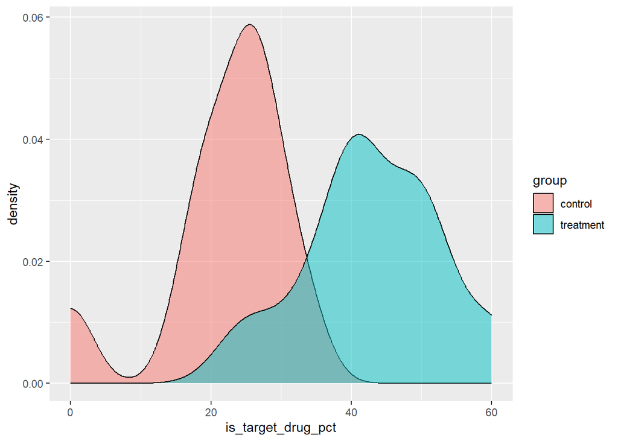

```r
#  density graph
ggplot(doctor_agg_dt, aes(x = is_target_drug_pct , fill=group)) +
  geom_density(alpha = 0.5)
```

```r
#Insight:Not perfect but sort of close to normal distribution for both groups
```

## Similiar variances

```r
doctor_agg_dt[ , var(is_target_drug_pct) , by ='group']
```

```
##        group       V1
## 1: treatment 97.88400
## 2:   control 84.60178
```

```r
#Insight:The ratio is less than 4 so this passes the variances test
```

# 5.T-test

```r
test_group_data <- doctor_agg_dt[group=='treatment']$is_target_drug_pct
control_group_data <- doctor_agg_dt[group=='control']$is_target_drug_pct

t.test(test_group_data, control_group_data, var.equal=TRUE)
```

```
##
##  Two Sample t-test
##
## data:  test_group_data and control_group_data
## t = 4.8925, df = 18, p-value = 0.0001172
## alternative hypothesis: true difference in means is not equal to 0
## 95 percent confidence interval:
##  11.92521 29.87479
## sample estimates:
## mean of x mean of y
##     43.12     22.22
```

# 6.conclusion

The campaign had a positive relative lift of 94%[(43.1-22.2)/(22.2)] for Feela-Good drug. This was statistically significant with a p-value < 0.001. The A/B testing showed that the campaign intervention was very effective in promoting the new drug. We should roll out more campaigns to doctors that share similar attributes to the test/control group.